```python
import numpy as np
import matplotlib.pyplot as plt
from scipy.stats import *
import statsmodels.api as sm
from datas.fixmat import *
```

# Dataset

- collection of eye movement data over 23 different studies
- fixation points are previously determined (raw gaze data won't be used)
- use data of "Baseline" study for assignments
- [link to dataset](https://datadryad.org/resource/doi:10.5061/dryad.9pf75)

### Baseline study

- free viewing
- 48 participants
- 255 different images in 4 categories
- randomized presentation for 6 seconds

[output not shown]

```python
# use a fixmat.py to load the hdf5 format data as a panda dataframe
df, meta = load('datas/etdb_v1.0.hdf5', "Baseline")
df.head()
```

|  | SUBJECTINDEX | category | dataset_nr | end | eye | filenumber | fix | pupil | start | trial | x | y |
| --- | --- | --- | --- | --- | --- | --- | --- | --- | --- | --- | --- | --- |
| 0 | 1.0 | 11.0 | 3.0 | 215.0 | 2.0 | 25.0 | 1.0 | 3287.901123 | -183.0 | 1.0 | 636.0 | 489.0 |
| 1 | 1.0 | 11.0 | 3.0 | 503.0 | 2.0 | 25.0 | 2.0 | 2872.182129 | 261.0 | 1.0 | 524.0 | 276.0 |
| 2 | 1.0 | 11.0 | 3.0 | 819.0 | 2.0 | 25.0 | 3.0 | 2452.396484 | 541.0 | 1.0 | 592.0 | 393.0 |
| 3 | 1.0 | 11.0 | 3.0 | 1103.0 | 2.0 | 25.0 | 4.0 | 2135.433594 | 865.0 | 1.0 | 367.0 | 339.0 |
| 4 | 1.0 | 11.0 | 3.0 | 1399.0 | 2.0 | 25.0 | 5.0 | 2007.327393 | 1145.0 | 1.0 | 196.0 | 364.0 |

```python
meta
```

```
{'# Fix.': 203772,
 '# Obs.': 48,
 'Age': '23.1 (19-28)',
 'Article': 15.0,
 'Categories': '7,8,10,11',
 'Disp. Size (degree)': '29x22',
 'Display': 'SM1100',
 'Display resolution (pixels)': '1280x960',
 'Eye Tracker': 'EL II',
 'ID': 3,
 'Img. Pos. (pixel)': '0,0',
 'Img. size (pixel)': '1280x960',
 'PPD': 45.6,
 'Sampling freq. (Hz)': '500 Hz',
 'Task': 'FV',
 'V. Dur.': '6s',
 'V. dist. (cm) ': 80,
 'Val. error (degrees)': 0.3}
```

# Q-Q plot

- used to compare two probability distributions
- plot quantiles against each other
- quantiles: dividing a probability distrbution in a way that each segment has a same probability

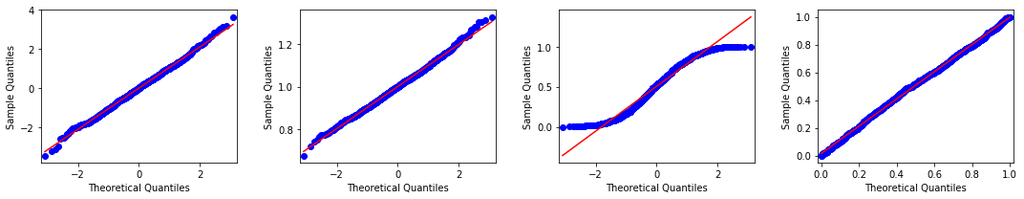

```python
data_uniform = uniform.rvs(size=1000)
# data_alpha = alpha.rvs(a=a,size=1000)
data_stdnorm = norm.rvs(size=1000)
data_norm = norm.rvs(size=1000, loc=1, scale=0.1)

fig, axes = plt.subplots(nrows=1, ncols=4, figsize=(15,3))

prob = sm.ProbPlot(data_stdnorm,dist="norm")
prob.qqplot(line="r", ax=axes[0])
prob = sm.ProbPlot(data_norm,dist="norm")
prob.qqplot(line="r", ax=axes[1])
prob = sm.ProbPlot(data_uniform,dist="norm")
prob.qqplot(line="r", ax=axes[2])
prob = sm.ProbPlot(data_uniform,dist="uniform")
prob.qqplot(line="r", ax=axes[3])

fig.tight_layout()
plt.show()
```

# Heatmap

- can be used to represent fixation probability of certain region in our case

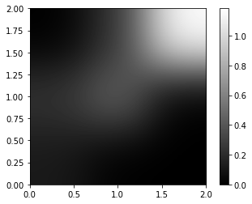

```python
x = [0,0,0,1,1,1,1,1,1,2,2,2,2,2,2,2,2,2,2]
y = [0,1,1,1,1,1,1,2,2,2,2,2,2,2,2,2,2,2,2]
H, xedges, yedges = np.histogram2d(x, y, bins=3, density=True)
plt.imshow(H.T, interpolation='gaussian', origin='low',
        extent=[xedges[0], xedges[-1], yedges[0], yedges[-1]], cmap="gray")
plt.colorbar()
```

### 1.c) visualizing data distribution

Are there any inter-subject difference and effect of different category in our data?

[figure not shown]

### 3.a) distribution of # fixation

Now we would like to know if there's a difference in terms of fixation numbers at different time segment.

[figure not shown]

### 3.b) leftward bias

If you took Action & Cognition I, you have probably heard about the leftward bias in human's fixation behavior. It is known that people tend to look more at the left visual field for the initial first second. Check whether this holds for our dataset as well.

- make a pointplot with x-axis as the x-coordinate of each fixation point and y-axis as the time bin to which the fixation point belongs to.
- make a vertical line at middle point of the x values. The x-coordinate of the fixation point in the data is based on the coordinate system using the display resolution. You can find out the information about display resolution by taking a look at the meta data.

[figure not shown]

### 4. Heatmap

Now let's use heatmap to visualize which part of pictures is fixated for how long. It would be also good to know if there's a difference between categories.

- make a heatmap for data consisting of each categories and then averaged across all data.
- mark a central point in the plot.
- you can use `numpy.histogram2d` to compute a bi-dimensional histogram.
- then you can use `pyplot.imshow` to plot these histogram.
- don't forget to use the parameter `extent` to control for the bounding box to which the image should fit in.
- if you want to use other functions that's surely fine as well.

[figure not shown]

### 5. Scanpath

We want to know whether different scan behaviour is used when viewing images of different categories. Scanpath is a path followed by the eyes when viewing a stimulus. Scanpaths are useful for analyzing cognitive intent, interest, and salience. It has an advantage to a heatmap because the information about temporal structure of viewing behaviour can be plotted.

- make four plots, one for each category.
- choose randomly one trial of which you will plot a scanpath.
- mark fixation points.
- plot the saccade path from one fixation point to another one.
- make sure that the order of fixation can be read out from the plot.
- also include information about the duration of each fixation. One way to do it is the use the size of the fixation marker.
- plot the background image superimposed with the scanpath.

[figure not shown]